# Exercise 2_2: Basic Raster Operations

Advanced Geospatial Data Processing for Social Scientists

Author

Dennis Abel & Stefan Jünger

In the next three exercises, we’ll dive into the world of raster data. You’ll practice importing different raster formats, explore the properties of spatial layers, and even create a new raster layer by combining datasets.

Along the way, you might encounter a few common challenges, like dealing with different coordinate systems. These are great opportunities to sharpen your spatial data skills!

Let’s jump in!

### Exercises

**Note🏋️ Exercise 1**

Import a raster `.tif` file from the `./data/z22` folder. Once loaded, explore its dimensions, resolution, and CRS.

Then think about the resolution: What area does a single grid cell cover in km²? (Hint: check the resolution units and do the math!)

**Caution💡 Tip**

You can use the `terra` package to load raster files. With the `terra::rast()` function, you’ll be able to load your `.tif` file and start working with it.

Use `terra::res()` to get the cell size. If the CRS uses meters, a 1000 × 1000 m cell = 1 km².

**Note🏋️ Exercise 2**

Now import a NetCDF file (`.nc`) from the `./data/z22` folder. Compare it to the `.tif` you loaded in Exercise 1: Do they have the same dimensions, resolution, and CRS? What differences do you notice between the two file formats?

**Caution💡 Tip**

`terra::rast()` also works for `.nc` files — same function, different format. Compare `dim()`, `terra::res()`, and `terra::crs()` between the two rasters. Pay attention to the CRS — NetCDF files sometimes use a different one than GeoTIFFs!

Note: Layer names in `.nc` files may look cryptic (e.g., `age_short_Z1=1`). To find out what each layer represents, check the [Census 2022 database](https://ergebnisse.zensus2022.de/datenbank/online/themes) or — if you have the `z22` package installed — try `z22::z22_categories("age_short")`.

**Note🏋️ Exercise 3**

Now it’s time to get creative! 🎨 Combine your two rasters to create a new, meaningful layer. Think about what operation makes sense given the variables you loaded — e.g., if you have population counts and a percentage, what could you calculate?

Give your result a meaningful variable name that reflects what it represents.

**Caution💡 Tip**

However, beware: Since the CRS of the two datasets might not match, you could encounter a warning. Take a moment to investigate and correct it!

- Check the CRS of both datasets with `terra::crs()`.
- If necessary, use `terra::project()` to align the CRS of both layers.
- Once aligned, you can perform mathematical operations like +, -, *, or / on the two layers.

### Solutions

**Tip✅ Solution 1**

```r
library(terra)
# Load a raster — here: share of population aged 65+
age_65_tif <- terra::rast("./data/z22/age_from_65.tif")

# Inspect metadata
age_65_tif # dimensions, resolution, CRS, value range
```

```
class       : SpatRaster
size        : 859, 641, 1  (nrow, ncol, nlyr)
resolution  : 1000, 1000  (x, y)
extent      : 4031000, 4672000, 2689000, 3548000  (xmin, xmax, ymin, ymax)
coord. ref. : ETRS89-extended / LAEA Europe (EPSG:3035)
source      : age_from_65.tif
name        :  cat_0
min value   :   0.26
max value   : 100.00
```

```r
dim(age_65_tif) # rows, columns, layers
```

```
[1] 859 641   1
```

```r
terra::res(age_65_tif) # cell size (in CRS units)
```

```
[1] 1000 1000
```

```r
# Cell area: resolution is 1000 × 1000 m = 1 km² per cell
terra::res(age_65_tif)[1] * terra::res(age_65_tif)[2] / 1000000 # in km²
```

```
[1] 1
```

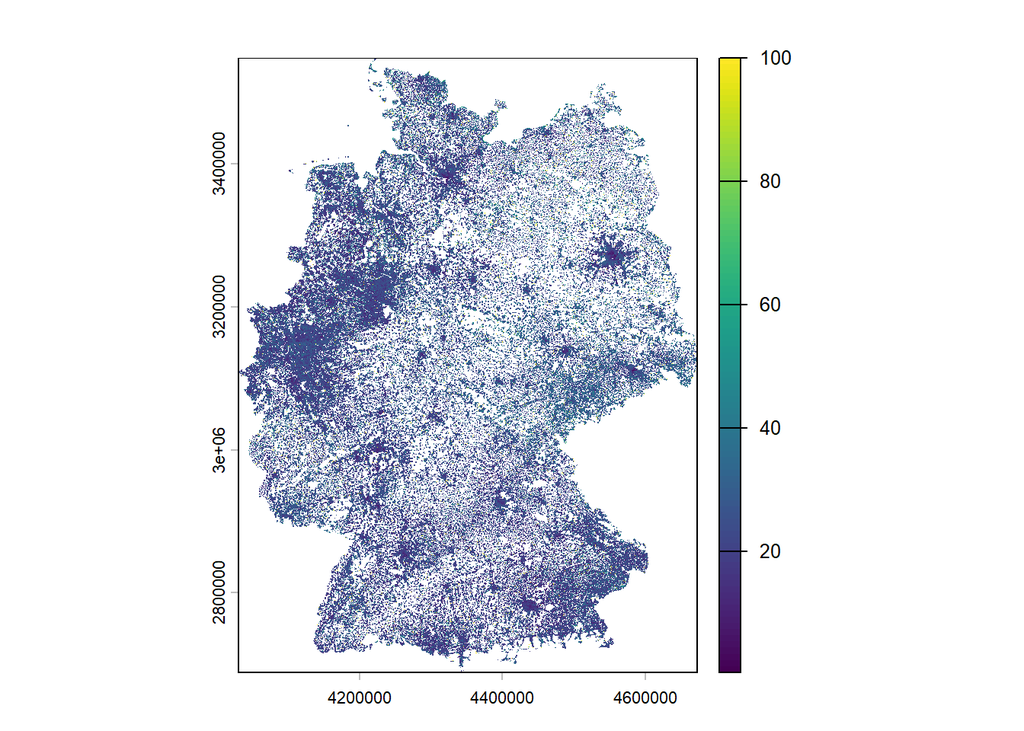

```r
# Visualize
plot(age_65_tif)
```

**Tip✅ Solution 2**

```r
# Load a NetCDF — unlike .tif, these can hold multiple layers
age_groups_nc <- terra::rast("./data/z22/age_short.nc")

# Compare with the .tif from Exercise 1
age_groups_nc # notice: multiple layers!
```

```
class       : SpatRaster
size        : 859, 641, 5  (nrow, ncol, nlyr)
resolution  : 1000, 1000  (x, y)
extent      : 4031000, 4672000, 2689000, 3548000  (xmin, xmax, ymin, ymax)
coord. ref. : ETRS89-extended / LAEA Europe (EPSG:3035)
source      : age_short.nc
names       : age_short_Z1=1, age_short_Z1=2, age_short_Z1=3, age_short_Z1=4, age_short_Z1=5
depth       : 1 to 5 (Z1: 5 steps)
```

```r
dim(age_groups_nc) # rows, cols, layers — more layers than the .tif
```

```
[1] 859 641   5
```

```r
terra::nlyr(age_groups_nc) # how many layers (= age groups)?
```

```
[1] 5
```

```r
terra::res(age_groups_nc) # resolution — same as the .tif?
```

```
[1] 1000 1000
```

```r
terra::crs(age_groups_nc, describe = TRUE)$code # CRS — same?
```

```
[1] "3035"
```

```r
# Each layer is a different age group
names(age_groups_nc) # what age groups are inside?
```

```
[1] "age_short_Z1=1" "age_short_Z1=2" "age_short_Z1=3" "age_short_Z1=4"
[5] "age_short_Z1=5"
```

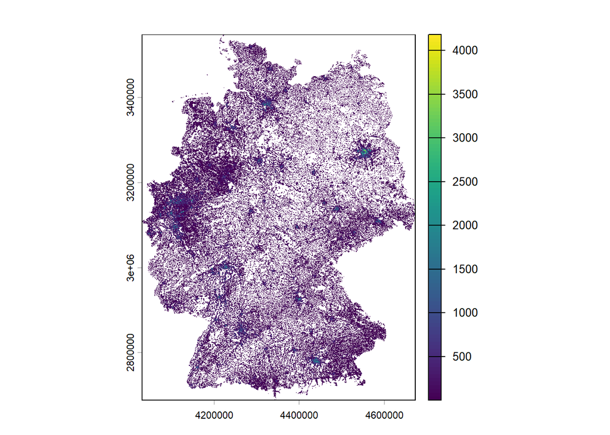

```r
# Visualize the first layer
plot(age_groups_nc[[1]])
```

**Tip✅ Solution 3**

```r
# Load a second .tif to combine with our age_65 layer
population_tif <- terra::rast("./data/z22/population.tif") # absolute counts

# Step 1: Check CRS — they must match for raster math!
terra::crs(age_65_tif, describe = TRUE)$code # age_65 CRS
```

```
[1] "3035"
```

```r
terra::crs(population_tif, describe = TRUE)$code # population CRS
```

```
[1] "3035"
```

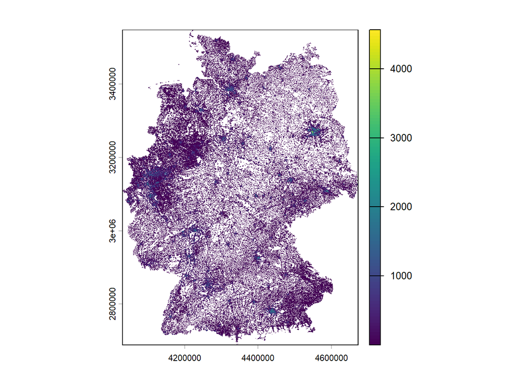

```r
# Step 2: If CRS differ, reproject one to match the other
if (terra::crs(age_65_tif) != terra::crs(population_tif)) {
  age_65_tif <- terra::project(age_65_tif, population_tif)
}

# Step 3: Raster algebra — create something meaningful
# age_65_tif is a percentage (0–100), population_tif is an absolute count
# Multiply to get the number of people aged 65+ per cell
older_population <- population_tif * (age_65_tif / 100)

# Visualize — where do most older people live?
plot(older_population)
```